# airline_data_visualization slides

### Bureau of Transportation Statistics Airline On-time Statistics and Delay Data Analysis

## by Cherie Goodenough

Demonstrate univariate, bivariate and multivariate data visualization using a large flight delay dataset from the FAA.

```python
df2008.head(10)
```

|  | Year | Month | DayofMonth | DayOfWeek | DepTime | CRSDepTime | ArrTime | CRSArrTime | UniqueCarrier | FlightNum | ... | TaxiIn | TaxiOut | Cancelled | CancellationCode | Diverted | CarrierDelay | WeatherDelay | NASDelay | SecurityDelay | LateAircraftDelay |
| --- | --- | --- | --- | --- | --- | --- | --- | --- | --- | --- | --- | --- | --- | --- | --- | --- | --- | --- | --- | --- | --- |
| 0 | 2008 | 1 | 3 | 4 | 2003.0 | 1955 | 2211.0 | 2225 | WN | 335 | ... | 4.0 | 8.0 | 0 | NaN | 0 | NaN | NaN | NaN | NaN | NaN |
| 1 | 2008 | 1 | 3 | 4 | 754.0 | 735 | 1002.0 | 1000 | WN | 3231 | ... | 5.0 | 10.0 | 0 | NaN | 0 | NaN | NaN | NaN | NaN | NaN |
| 2 | 2008 | 1 | 3 | 4 | 628.0 | 620 | 804.0 | 750 | WN | 448 | ... | 3.0 | 17.0 | 0 | NaN | 0 | NaN | NaN | NaN | NaN | NaN |
| 3 | 2008 | 1 | 3 | 4 | 926.0 | 930 | 1054.0 | 1100 | WN | 1746 | ... | 3.0 | 7.0 | 0 | NaN | 0 | NaN | NaN | NaN | NaN | NaN |
| 4 | 2008 | 1 | 3 | 4 | 1829.0 | 1755 | 1959.0 | 1925 | WN | 3920 | ... | 3.0 | 10.0 | 0 | NaN | 0 | 2.0 | 0.0 | 0.0 | 0.0 | 32.0 |
| 5 | 2008 | 1 | 3 | 4 | 1940.0 | 1915 | 2121.0 | 2110 | WN | 378 | ... | 4.0 | 10.0 | 0 | NaN | 0 | NaN | NaN | NaN | NaN | NaN |
| 6 | 2008 | 1 | 3 | 4 | 1937.0 | 1830 | 2037.0 | 1940 | WN | 509 | ... | 3.0 | 7.0 | 0 | NaN | 0 | 10.0 | 0.0 | 0.0 | 0.0 | 47.0 |
| 7 | 2008 | 1 | 3 | 4 | 1039.0 | 1040 | 1132.0 | 1150 | WN | 535 | ... | 7.0 | 7.0 | 0 | NaN | 0 | NaN | NaN | NaN | NaN | NaN |
| 8 | 2008 | 1 | 3 | 4 | 617.0 | 615 | 652.0 | 650 | WN | 11 | ... | 6.0 | 19.0 | 0 | NaN | 0 | NaN | NaN | NaN | NaN | NaN |
| 9 | 2008 | 1 | 3 | 4 | 1620.0 | 1620 | 1639.0 | 1655 | WN | 810 | ... | 3.0 | 6.0 | 0 | NaN | 0 | NaN | NaN | NaN | NaN | NaN |

10 rows × 29 columns

### Structure of dataset

> The data consist of two csv files with 29 columns, described below. The files are quite large, with 5M+ rows of observations per year. Note that the 1998 dataset does not have information on the reason for the delays that is present in the 2008 dataset.

### Main feature(s) of interest

> There are a lot of interesting features in this data. Investigations into delays as a function of time of day, day of the week, month, departure and arrival airports, carrier, and scheduled flight time (scheduled arrival minus scheduled departure) could all produce interesting analysis. Having data for two years a decade apart allows for the investigation of long-term changes in delays.

### What features in the dataset do you think will help support your investigation into your feature(s) of interest?

> For this visualization, I will compare overall delays and by airline to look for changes in the decade between 1998 and 2008.

Note that ["NAS Delay. Delay that is within the control of the National Airspace System (NAS) may include: non-extreme weather conditions, airport operations, heavy traffic volume, air traffic control, etc. Delays that occur after Actual Gate Out are usually attributed to the NAS and are also reported through OPSNET."](https://aspmhelp.faa.gov/index.php/Types_of_Delay)

```python
pd.set_option('display.max_colwidth',-1)
dfcols
```

|  | Name | Description |
| --- | --- | --- |
| 0 | Year | 1987-2008 |
| 1 | Month | 12-Jan |
| 2 | DayofMonth | 31-Jan |
| 3 | DayOfWeek | 1 (Monday) - 7 (Sunday) |
| 4 | DepTime | actual departure time (local, hhmm) |
| 5 | CRSDepTime | scheduled departure time (local, hhmm) |
| 6 | ArrTime | actual arrival time (local, hhmm) |
| 7 | CRSArrTime | scheduled arrival time (local, hhmm) |
| 8 | UniqueCarrier | unique carrier code |
| 9 | FlightNum | flight number |
| 10 | TailNum | plane tail number |
| 11 | ActualElapsedTime | in minutes |
| 12 | CRSElapsedTime | in minutes |
| 13 | AirTime | in minutes |
| 14 | ArrDelay | arrival delay, in minutes |
| 15 | DepDelay | departure delay, in minutes |
| 16 | Origin | origin IATA airport code |
| 17 | Dest | destination IATA airport code |
| 18 | Distance | in miles |
| 19 | TaxiIn | taxi in time, in minutes |
| 20 | TaxiOut | taxi out time in minutes |
| 21 | Cancelled | was the flight cancelled? |
| 22 | CancellationCode | reason for cancellation (A = carrier, B = weather, C = NAS, D = security) |
| 23 | Diverted | 1 = yes, 0 = no |
| 24 | CarrierDelay | in minutes |
| 25 | WeatherDelay | in minutes |
| 26 | NASDelay | in minutes |
| 27 | SecurityDelay | in minutes |
| 28 | LateAircraftDelay | in minutes |

#### Define:

Drop delay reasons columns, since these were not reported in 1998.

#### Code:

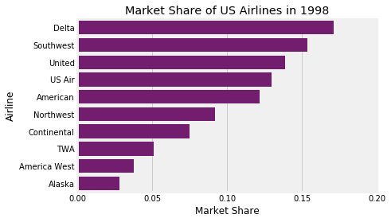

```python
ticks98 = np.arange(0,max98+.05, .05)
tnames98 = ['{:0.2f}'.format(i) for i in ticks98]
airline_order = (df98clean.Airline.value_counts()).index
ytnames98 = ['Delta','Southwest','United','US Air','American','Northwest',
                'Continental','TWA','America West','Alaska']
sb.countplot(data=df98clean,y='Airline',order=(df98clean.Airline.value_counts()).index,color=sb.color_palette()[5])
plt.xticks(ticks98*flights98,tnames98)
plt.yticks(np.arange(10),ytnames98)
#plt.set(yticklabels = )
plt.title('Market Share of US Airlines in 1998')
plt.xlabel('Market Share');
```

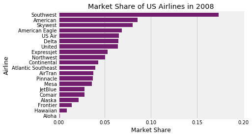

```python
ticks08 = np.arange(0,max08+.05, .05)
tnames08 = ['{:0.2f}'.format(i) for i in ticks08]
ytnames08 = ['Southwest','American','Skywest','American Eagle','US Air','Delta','United','Expressjet','Northwest',
            'Continental','Atlantic Southeast','AirTran','Pinnacle','Mesa','JetBlue','Comair','Alaska',
            'Frontier','Hawaiian','Aloha']
airline_order = (df08clean.Airline.value_counts()).index
sb.countplot(data=df08clean,y='Airline',order=(df08clean.Airline.value_counts()).index,color=sb.color_palette()[5])
plt.xticks(ticks08*flights08,tnames08)
plt.yticks(np.arange(20),ytnames08)
plt.title('Market Share of US Airlines in 2008')
plt.xlabel('Market Share');
```

Over the decade from 1998 to 2008 Southwest became the largest airline, increasing their market share from 15.1% to 17.1%. More interestingly, market share became much less evenly distributed. With the entry of 10 more airlines* and Southwest slightly increasing their share, the other major airlines in 1998 all lost significantly.

* This might be a change in airlines reporting into the system, rather than an actual increase in airlines

Now lets look at overall delays.

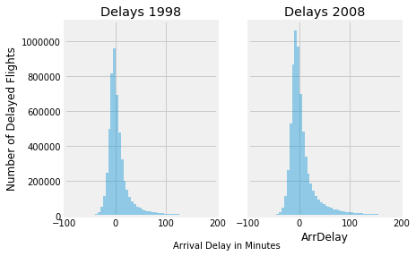

```python
f, axes = plt.subplots(1,2,sharex='all',sharey='all')
sb.distplot(df98clean.ArrDelay,ax=axes[0],kde=False,bins=dbins)
sb.distplot(df08clean.ArrDelay, ax=axes[1],kde=False,bins=dbins)
f.text(0.5,0,'Arrival Delay in Minutes',ha='center')
plt.xlim(-100,200)
axes[0].set_xlabel('')
axes[0].set_ylabel('Number of Delayed Flights')
axes[0].set_title('Delays 1998')
axes[1].set_title('Delays 2008');
```

### Discuss the distribution(s) of your variable(s) of interest. Were there any unusual points? Did you need to perform any transformations?

> The shape of the delay distributions has remained the same over the decade from 1998-2008. This indicates that there have been no major, structural changes that have significantly improved or worsened delays in that decade.

### Of the features you investigated, were there any unusual distributions? Did you perform any operations on the data to tidy, adjust, or change the form of the data? If so, why did you do this?

> There were no unusual distributions identified.

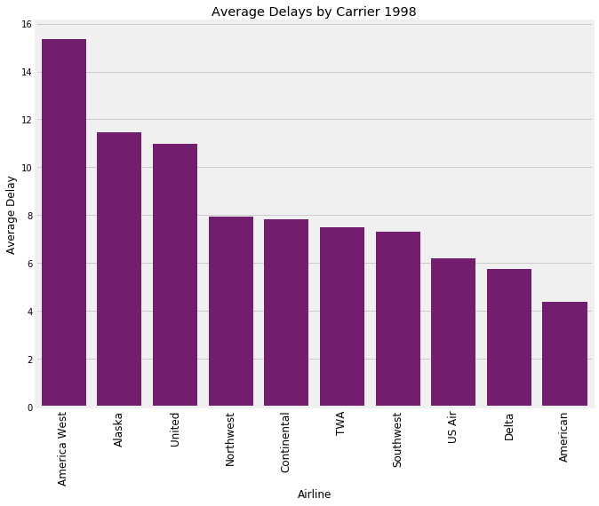

```python
# carrier_delay98 = df98clean.groupby(['Airline'])['ArrDelay'].mean().reset_index().rename(columns={0:'avg_delay'})
delay_order = carrier_delay98.sort_values('ArrDelay', ascending=False)
plt.figure(figsize=[10,8])
base_color= sb.color_palette()[5]
sb.barplot(data= delay_order, x='Airline', y='ArrDelay', color=base_color,)
plt.xticks(np.arange(10), ('America West','Alaska','United','Northwest','Continental','TWA','Southwest','US Air','Delta','American'), rotation=90, fontsize = 12)
plt.ylabel('Average Delay')
plt.title('Average Delays by Carrier 1998');
```

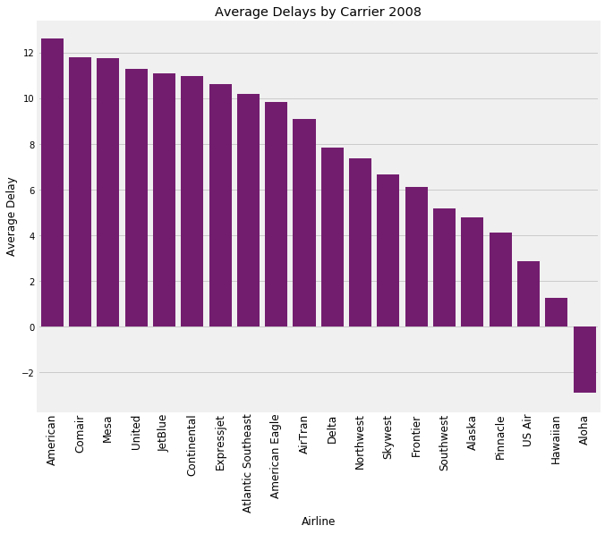

```python
carrier_delay = df08clean.groupby(['Airline'])['ArrDelay'].mean().reset_index().rename(columns={0:'avg_delay'})
delay_order = carrier_delay.sort_values('ArrDelay', ascending=False)
plt.figure(figsize=[10,8])
base_color= sb.color_palette()[5]
sb.barplot(data= delay_order, x='Airline', y='ArrDelay', color=base_color)
plt.xticks(np.arange(20), ('American','Comair','Mesa','United','JetBlue','Continental','Expressjet','Atlantic Southeast',
                           'American Eagle','AirTran','Delta','Northwest','Skywest','Frontier','Southwest','Alaska','Pinnacle',
                           'US Air','Hawaiian','Aloha'), rotation=90, fontsize = 12)
plt.ylabel('Average Delay')
plt.title('Average Delays by Carrier 2008');
```

### Talk about some of the relationships you observed in this part of the investigation. How did the feature(s) of interest vary with other features in the dataset?

> American Airlines went from having the best on-time record in 1998 to having the worst in 2008. That said, no airline in 2008 had average delays worse than the worst airline in 1998.

[figure not shown]

```python
fig = plt.figure(1,figsize=(10,7))
ax = sb.countplot(y='Airline', hue= 'delay', data= df98clean)
ax.yaxis.label.set_visible(False)
plt.xlabel('Flights', fontsize=14, weight = 'bold')
plt.xticks([0, 2e5, 4e5, 6e5, 8e5], ['0', '200K', '400K', '600K', '800K'])
plt.setp(ax.get_yticklabels(), fontsize=12, weight = 'bold');
fig.suptitle('On time records of Carriers 1998',fontsize=16)
ax.set_yticklabels({'Southwest','America West','Continental','US Air','Delta','United','American','Northwest','Alaska','TWA'})
legend = plt.legend()
legend.get_texts()[0].set_text('on time (t < 10 min)')
legend.get_texts()[1].set_text('small delay (1- < t < 60 min)')
legend.get_texts()[2].set_text('large delay (t > 60 min)')
```

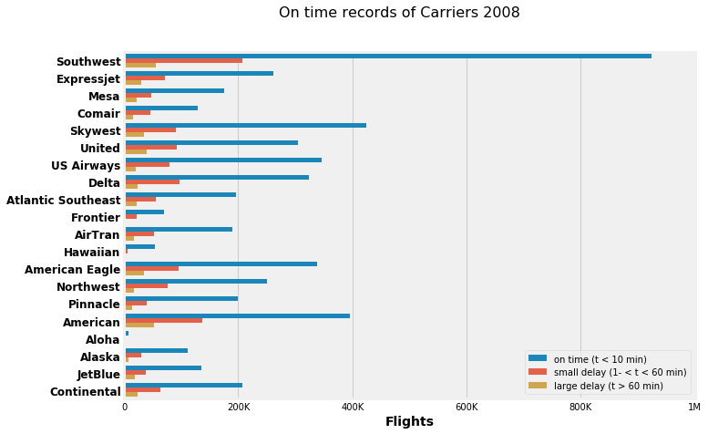

```python
fig = plt.figure(1, figsize=(10,7))
ax = sb.countplot(y='Airline', hue= 'delay', data= df08clean)
ax.yaxis.label.set_visible(False)
plt.xlabel('Flights', fontsize=14, weight = 'bold')
plt.xticks([0, 2e5, 4e5, 6e5, 8e5,1e6], ['0', '200K', '400K', '600K', '800K','1M'])
plt.setp(ax.get_yticklabels(), fontsize=12, weight = 'bold');
fig.suptitle('On time records of Carriers 2008',fontsize=16)
yticks = [item.get_text() for item in ax.get_yticklabels()]
yticks = ['Southwest','Expressjet','Mesa','Comair','Skywest','United','US Airways','Delta','Atlantic Southeast','Frontier',
          'AirTran','Hawaiian','American Eagle','Northwest','Pinnacle','American','Aloha','Alaska','JetBlue','Continental']
ax.set_yticklabels(yticks)
legend = plt.legend()
legend.get_texts()[0].set_text('on time (t < 10 min)')
legend.get_texts()[1].set_text('small delay (1- < t < 60 min)')
legend.get_texts()[2].set_text('large delay (t > 60 min)')
plt.show()
```

This is a rich dataset which would allow for deep exploration of the causes of delays, which airlines have the best and worst records, and which airports experience the best and worst records of on-time arrival. There was nothing particularly surprising in the features of this dataset that were investigated.